# UN General Assembly Voting

Ali Gharaee

December 3, 2017

# Summery

This data provides the voting history of countries in the United Nations General Assembly, along with information such as date, description, and topics for each vote. In this exploratoy analysis I will explore the historical voting of the United Nations General Assembly, including analyzing differences in voting between countries, across time, and among international issue.

Orginal dataset come from the **kaggle** *UN General Assembly Votes, 1946-2015*. see [Kaggle UN dataset](https://www.kaggle.com/unitednations/general-assembly) for value’s detail explanation.

This dataset originaly come form *Erik Voeten Dataverse* see [United Nations General Assembly Voting Data](https://dataverse.harvard.edu/dataset.xhtml?persistentId=hdl:1902.1/12379)

## Packages instalation

```r
library(tidyverse)
library(readr)
library(countrycode)
```

## Data Import

`Votes` dataset contains the history of each country’s vote. The `resolutions` dataset shows relationships betwen each vote and 6 UN resolutions.

```r
votes <- read_csv("votes.csv")
resolutions <- read_csv("resolutions.csv")
```

### Section 1: Data Exploration

Start with`votes` data. In this dataset : * The vote column has 5 numbers that represents that country’s vote: 1 = yes, 2 = Abstain, 3 = No, 8 = Not present and 9 = Not a member

use `dplyr::filter` to remove rows that I am not interested in (8,9)

First session of the UN was held in 1946 and and holds one session per year.* use `dplyr::mutate` to convert session coloum to a new coloum to make them more informative and easier to work with.

The country codes in the ccode column are what is called: [Correlates of War codes](http://cow.dss.ucdavis.edu/data-sets/cow-country-codes). I used the *countrycode* package to translate ccode to country names.

Use `dplyr::summarize` to calculate *% of votes that are yes* . It shows the country tends to agree with international consensus(vote = 1 means yes).

Finally use `dplyr::arrange` to find the countries that voted “yes” least often over time

```r
votes_tidy <- votes %>%
  filter(vote <= 3) %>%
  mutate(year = session + 1945 ,
         country = countrycode(ccode,"cown", "country.name" )) %>%
  select(-c(session,ccode)) %>%
  group_by(year , country) %>%
  summarize( total = n() , percent_yes = mean(vote == 1)) %>%
  filter(total > 100) %>% # remove countries that have fewer than 100 votes.
  arrange(percent_yes) %>%
  ungroup()
```

+USA +Denmark +Norway +Sweden +France +Israel

Use the *ggplot2* package to turn your results into a visualization of the percentage of “yes” votes over time for 6 countries:

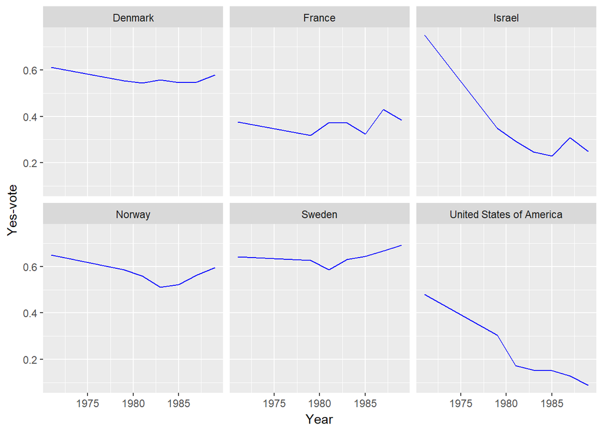

```r
subject_country <- votes_tidy %>%
  filter(country %in% c("United States of America" , "Denmark" ,
                        "Norway", "Sweden" , "Israel" , "France"))

subject_country %>%
  ggplot(aes( x = year , y = percent_yes)) +
  geom_line(color = "blue") +
  scale_x_continuous("Year") +
  scale_y_continuous("Yes-vote") +
  facet_wrap(~ country)
```

Similarly, we have agreeableness relationship between Scandinavian countries (Norway, Sweden, Denmark), USA and Israel on the same graph, using color to distinguish each country:

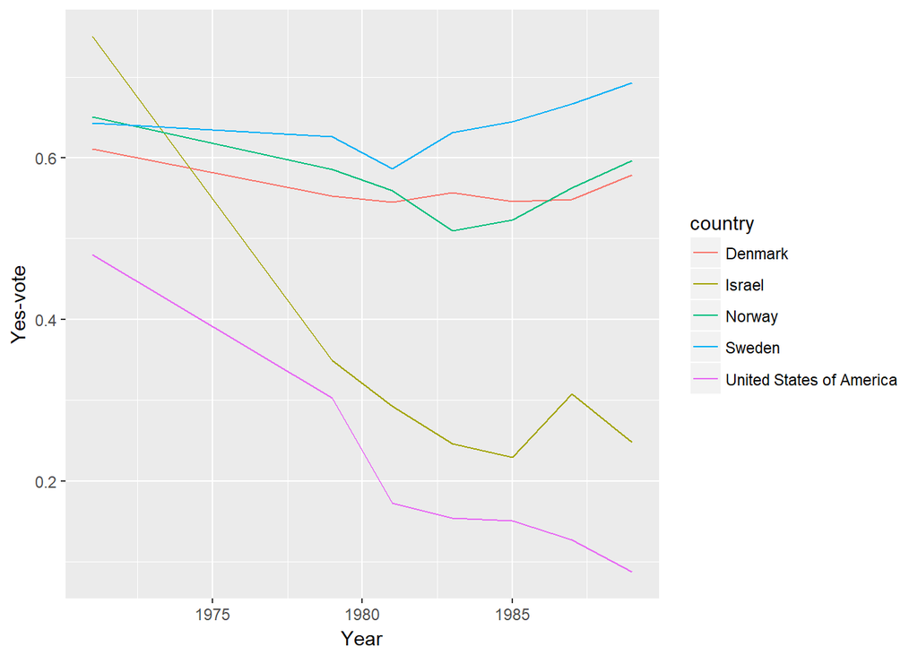

### Section 2: Data Modelling

A linear regression is a model that examine how one variable changes with respect to another by fitting a best fit line.

Model the trend with liner regression, finding the best fit line Tidying model with *broom* package.

```r
library(broom)
```

At this point, analyses will involve joining the votes and resolutions datasets which includes topic information about each country, to be able to analyze votes within particular topics. Then use `tidyr::gather` to tidy the new dataset for further analysis.

### Data preparation

```r
votes_tidy2 <- votes %>%
  filter(vote <= 3) %>%
  mutate(year = session + 1945 ,
         country = countrycode(ccode,"cown", "country.name" )) %>%
  inner_join(resolutions, by = c("rcid", "session")) %>%
  gather(topic, has_topic , me:ec) %>%
  filter(has_topic == 1) %>%
  select(country, year, vote, topic, has_topic) %>%
  #recode the data to replace these codes with their full name
  mutate(topic = recode(topic,
                        me = "Palestinian conflict",
                        nu = "Nuclear weapons",
                        di = "Arms control and disarmament",
                        hr = "Human rights",
                        co = "Colonialism",
                        ec = "Economic development"))
```

## Data modelling

Summarize the votes for each combination of country, year, and topic

```r
(country_year_topic <- votes_tidy2 %>%
  group_by(country, year, topic) %>%
  summarize( total = n() , percent_yes = mean(vote == 1)) %>%
  ungroup()  )
```

```
## # A tibble: 26,968 x 5
##        country  year                        topic total percent_yes
##          <chr> <dbl>                        <chr> <int>       <dbl>
##  1 Afghanistan  1947                  Colonialism     8   0.5000000
##  2 Afghanistan  1947         Economic development     1   0.0000000
##  3 Afghanistan  1947                 Human rights     1   0.0000000
##  4 Afghanistan  1947         Palestinian conflict     6   0.0000000
##  5 Afghanistan  1949 Arms control and disarmament     3   0.0000000
##  6 Afghanistan  1949                  Colonialism    22   0.8636364
##  7 Afghanistan  1949         Economic development     1   1.0000000
##  8 Afghanistan  1949                 Human rights     3   0.0000000
##  9 Afghanistan  1949              Nuclear weapons     3   0.0000000
## 10 Afghanistan  1949         Palestinian conflict    11   0.8181818
## # ... with 26,958 more rows
```

Modelling for each country has 4 steps: +Divided the data for each country into a separate dataset in the data column. `tidyr::nest` all columns except country and topic, which will result in a data frame with one row per country-topic. + Use `purrr::map` by applying liner regression to each item. + Use `purrr::map` again to tidy `broom::tidy` each model in the dataset. + Use `tidyr::unnest`to combine all of those into a large data frame.

Then filter the slope of each model (term = year) to see how each is changing over timeand. Also filter out random noise in p.value to extract only cases that are statistically significant.

Finnaly use `dplyr::arrange` to find the countries with the highest and lowest slopes (the estimate column)

Countries has the steepest downward trend in Colonialism (goes agnasit UN resolution):

```r
(country_coef_model <- country_year_topic %>%
  nest(-country, -topic) %>%
  mutate( model = map(data, ~lm(percent_yes ~ year , .))) %>%
  mutate(tidied = map(model, tidy)) %>%
  unnest(tidied) %>%
  filter ( term == "year" , p.adjust(p.value) < 0.05 ,
           topic == "Colonialism") %>%
  arrange (estimate))
```

```
## # A tibble: 26 x 7
##                       country       topic  term     estimate    std.error
##                         <chr>       <chr> <chr>        <dbl>        <dbl>
##  1                     Israel Colonialism  year -0.009529337 0.0017706645
##  2   United States of America Colonialism  year -0.007473819 0.0009222886
##  3                   Pakistan Colonialism  year  0.004277785 0.0008367695
##  4                      Egypt Colonialism  year  0.004941763 0.0009449754
##  5                Afghanistan Colonialism  year  0.005106200 0.0009885245
##  6                   Malaysia Colonialism  year  0.005597429 0.0010631137
##  7                   Thailand Colonialism  year  0.005754159 0.0011343229
##  8                      India Colonialism  year  0.005858268 0.0010665963
##  9 Iran (Islamic Republic of) Colonialism  year  0.006048075 0.0009691037
## 10                       Cuba Colonialism  year  0.006337732 0.0011236394
## # ... with 16 more rows, and 2 more variables: statistic <dbl>,
## #   p.value <dbl>
```

Countries has the steepest upward trend in Colonialism:

```r
(country_coef_model <- country_year_topic %>%
  nest(-country, -topic) %>%
  mutate( model = map(data, ~lm(percent_yes ~ year , .))) %>%
  mutate(tidied = map(model, tidy)) %>%
  unnest(tidied) %>%
  filter( term == "year" , p.adjust(p.value) < 0.05 ,
           topic == "Colonialism") %>%
  arrange(desc(estimate) )  )
```

```
## # A tibble: 26 x 7
##                             country       topic  term    estimate
##                               <chr>       <chr> <chr>       <dbl>
##  1                     South Africa Colonialism  year 0.016574451
##  2                      New Zealand Colonialism  year 0.010865002
##  3 Saint Vincent and the Grenadines Colonialism  year 0.010811672
##  4                            Spain Colonialism  year 0.009479393
##  5                        Nicaragua Colonialism  year 0.009464870
##  6                            Chile Colonialism  year 0.009323302
##  7 Bolivia (Plurinational State of) Colonialism  year 0.008524197
##  8               Dominican Republic Colonialism  year 0.008422279
##  9                          Austria Colonialism  year 0.008353305
## 10                           Brazil Colonialism  year 0.008271821
## # ... with 16 more rows, and 3 more variables: std.error <dbl>,
## #   statistic <dbl>, p.value <dbl>
```

Visualizing trends in topics for Norway over time:

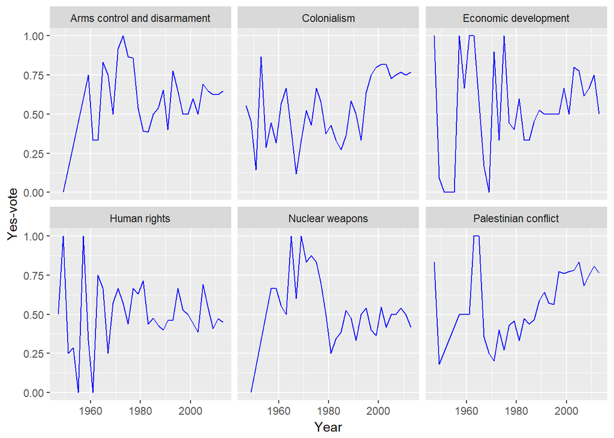

```r
country_year_topic %>%
  filter (country == "Norway") %>%
  ggplot(aes(year, percent_yes ))+
    geom_line(color = "blue")+
    facet_wrap(~ topic)+
    scale_x_continuous("Year") +
    scale_y_continuous("Yes-vote")
```